# Homework3

Arden Chaing

Phys 434

October 22nd 2020

Homework 3

```python
# neccessary imports for the assignment
%matplotlib inline
import numpy as np
import matplotlib
import matplotlib.pyplot as plt
import scipy as sp
from scipy import stats
import pandas as pd
import PIL
from PIL import Image, ImageDraw, ImageFilter
```

```python
# 1.A:
alg1_trueBird = 45
alg1_truePerson = 47
alg1_falseBird = 5
alg1_falsePerson = 3

alg2_trueBird = 47
alg2_truePerson = 42
alg2_falseBird = 11
alg2_falsePerson = 1

alg1_birdSuccess = (alg1_trueBird) / (alg1_trueBird + alg1_falsePerson)
alg1_personSuccess = (alg1_truePerson) / (alg1_truePerson + alg1_falseBird)
alg1_totalSuccess = (alg1_trueBird + alg1_truePerson) / (alg1_trueBird + alg1_truePerson + alg1_falseBird + alg1_falsePerson)
alg2_birdSuccess = (alg2_trueBird) / (alg2_trueBird + alg2_falsePerson)
alg2_personSuccess = (alg2_truePerson) / (alg2_truePerson + alg2_falseBird)
alg2_totalSuccess = (alg2_trueBird + alg2_truePerson) / (alg2_trueBird + alg2_truePerson + alg2_falseBird + alg2_falsePerson)

print("NN true total success:", alg1_totalSuccess)
print("NA true total success:", alg2_totalSuccess)
```

```
NN true total success: 0.92
NA true total success: 0.8811881188118812
```

Problem 1.A: Seen above we have calcualted the probabilities of successfully identifying birds, people, and both in each respective algorithm; neural network and new algorithm. Overall we can see that the neural network (92%) has a higher success rate at identifying both birds and people than the new algorithm (88%). Therefore NN makes fewer mistakes than NA.

```python
print("NN true bird success:", alg1_birdSuccess)
print("NN true person success:", alg1_personSuccess)
print("NA true bird success:", alg2_birdSuccess)
print("NA true person success:", alg2_personSuccess)
```

```
NN true bird success: 0.9375
NN true person success: 0.9038461538461539
NA true bird success: 0.9791666666666666
NA true person success: 0.7924528301886793
```

Problem 1.B: However, despite NA having a lower success rate at identifying both birds and people, it does correctly identify more birds than NN; NN has a rate of 94% while NA has a rate of 98%. Therefore, the new algorithm would be better suited for a zoo since it keeps less birds from escaping the aviary.

```python
# 1.C:
alg1_trueBird = alg1_birdSuccess * 99
alg1_truePerson = alg1_personSuccess * 1
alg1_falseBird = (1-alg1_birdSuccess) * 99
alg1_falsePerson = (1-alg1_personSuccess) * 1

alg2_trueBird = alg2_birdSuccess * 99
alg2_truePerson = alg2_personSuccess * 1
alg2_falseBird = (1-alg2_birdSuccess) * 99
alg2_falsePerson = (1-alg2_personSuccess) * 1

print("NN Bird True Bird:", alg1_trueBird)
print("NN Bird True Person", alg1_falsePerson)
print("NN Person True Bird:", alg1_falseBird)
print("NN Person True Person:", alg1_truePerson)
print()
print("NN Bird True Bird:", alg2_trueBird)
print("NN Bird True Person", alg2_falsePerson)
print("NN Person True Bird:", alg2_falseBird)
print("NN Person True Person:", alg2_truePerson)
```

```
NN Bird True Bird: 92.8125
NN Bird True Person 0.09615384615384615
NN Person True Bird: 6.1875
NN Person True Person: 0.9038461538461539

NN Bird True Bird: 96.9375
NN Bird True Person 0.2075471698113207
NN Person True Bird: 2.0625000000000036
NN Person True Person: 0.7924528301886793
```

Problem 1.C: Above are the truth tables knowing that with the pandemic only 1% of visitors will be people and the remaining 99% will be the birds. Using a sample size of 100, similar to a and b, I reversed engineered the values both algorithms would identify during the pandemic. Since we already calculated the success rate for people and for birds in both algorithms, you can multiply those probabilities by the expected amount of birds and humans (99 and 1 respectively) to yield the new values. Also we can calculate the false positives by taking 1 - true positives.

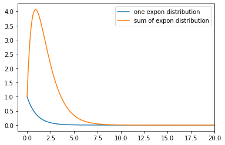

```python
# 2.A:
x = np.linspace(0,100,1001)
xc = np.linspace(0,200,2001)
ex1 = stats.expon.pdf(x)
ex2 = stats.expon.pdf(x)
both = np.convolve(ex1,ex2)
fig, ax = plt.subplots(1)
ax.plot(x,ex1, label='one expon distribution')
ax.plot(xc, both, label='sum of expon distribution')
ax.set_xlim([-1,20])
plt.legend(loc='best')
plt.show()
```

Problem 2.A: The pdf of the sum of two identical exponential distribution is plotted above along with the pdf of just one signle exponential distribution. xe^-(lambda * x) looks like an unnormalized gamma distrbution with alpha = 2.

```python
# 2.B:
Image.open('Homework3.1.jpg')
```

[output not shown]

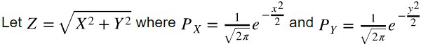

```python
# 2.C:
Image.open('Homework3.2.jpg')
```

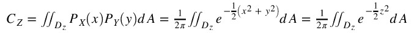

```python
Image.open('Homework3.3.jpg')
```

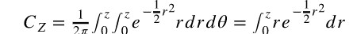

```python
 Image.open('Homework3.4.jpg')
```

[output not shown]

```python
Image.open('Homework3.5.jpg')
```

[output not shown]